# Effect Size Estimation

April 19, 2025

```r
suppressMessages(library(ramp.xds))
suppressMessages(library(ramp.work))
suppressMessages(library(ramp.control))
```

Everything we’ve done so far is merely reconstructing history, a purely descriptive exercise. The problem we must confront now is how to estimate the effect sizes of malaria control when we know:

- The timing of IRS mass spraying, approximate coverage, and the insecticide used
- The timing of ITN mass distributions, approximate ownership and use over time, and the type of bed net used

We start with a made-up problem, for illustration. Suppose:

This picture:

```r
set.seed(136)
tt0 <-  365*(0:6)
yy0 <-  c(.9, 2.2, 1.8, .2, .3, 1.4, 1.1)
yy0 <- yy0/mean(yy0)
mod1 <- xds_setup_cohort(
  eir = 2/365,
  season_par = makepar_F_sin(bottom=.1),
  trend_par = makepar_F_spline(tt=tt0, yy=yy0)
)
tt <- seq(0, 365*6, by = 30)
mod1 <- xds_solve_cohort(mod1, times=tt)
mod1 <- last_to_inits(mod1)
mod1 <- xds_solve_cohort(mod1, times=tt)
true_pr <- get_XH(mod1)$true_pr
obs_pr = true_pr*rlnorm(length(tt), 0, .3)
```

[figure not shown]

## Baseline

```r
ix = c(4,5)
cf_max <- make_cf_base_max(ix, mod1)
cf_min <- make_cf_base_min(ix, mod1)
cf_median <- make_cf_base_median(ix, mod1)
cf_mean <- make_cf_base_mean(ix, mod1)
```

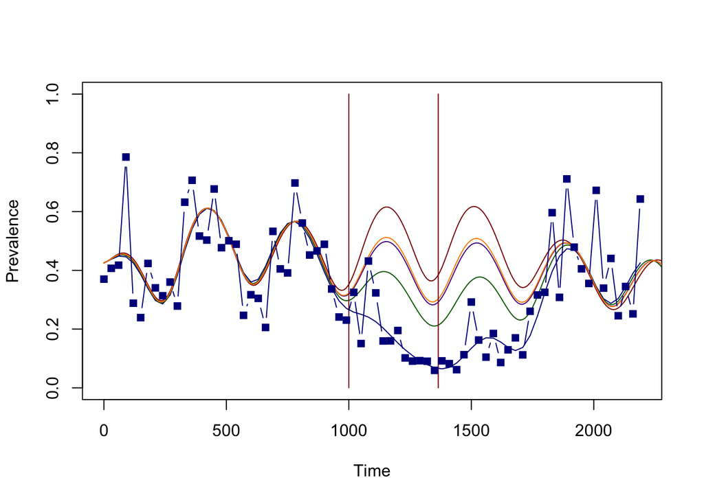

```r
mod1a <- modify_baseline(mod1, cf_max)
mod1b <- modify_baseline(mod1, cf_min)
mod1c <- modify_baseline(mod1, cf_median)
mod1d <- modify_baseline(mod1, cf_mean)
base_pr <- get_XH(mod1c)$true_pr
xds_plot_PR(mod1, clrs="darkblue")
xds_plot_PR(mod1a, clrs = "darkred", add=TRUE)
xds_plot_PR(mod1b, clrs = "darkgreen", add=TRUE)
xds_plot_PR(mod1c, clrs = "purple4", add=TRUE)
xds_plot_PR(mod1d, clrs = "darkorange", add=TRUE)
segments(1000, 0, 1000, 1, col = "darkred")
segments(1365, 0, 1365, 1, col = "darkred")
lines(tt, obs_pr, col = "darkblue", type = "b", pch=15)
```

Everything we’ve done so far has worked with an EIR-forced model. If we want to estimate effect sizes of control in some sensible way, we will need to fit a model that is forced by mosquito ecology:

```r
Lo <- list(
  Lambda = 50,
  season_par = makepar_F_sin(),
  trend_par = makepar_F_spline(tt0, tt0*0+1)
)
```

```r
mod <- xds_setup(Lopts = Lo, MYZname = "SI")
mod <- setup_travel_eir(mod, travelEIR = 1/3650/5)
mod <- xds_solve(mod, 3650, 3650)
mod <- last_to_inits(mod)
```

```r
mod <- pr2Lambda_history(obs_pr, tt, mod, twice=TRUE)
```

```r
mod <- xds_solve(mod, 6*365, 10)
```

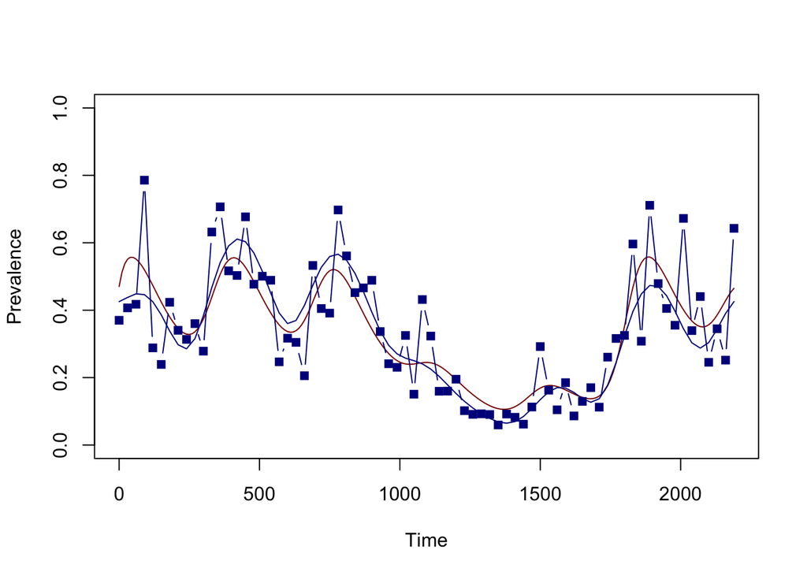

```r
xds_plot_PR(mod, clrs = "darkred")
xds_plot_PR(mod1, clrs="darkblue", add=TRUE)
lines(tt, obs_pr, col = "darkblue", type = "b", pch=15)
```

```r
irs1 <- list(
  t_init = c(1000, 1365),
  irs_type = c("actellic", "bendiocarb"),
  coverage = c(0.9, 0.9),
  zap = c(0.5, .3)
)
rounds <- setup_irs_multiround(opts=irs1)
```

```r
mod_irs <- setup_irs(mod, effectsizes_name = "simple",
                          coverage_name = "func",
                          coverage_opts = list(mx=1, trend_par=rounds))
```

```r
devtools::load_all()
```

```
## ℹ Loading ramp.work
```

```r
mod_est <- estimate_effect_sizes(mod_irs, obs_pr[-1], tt, irs_rounds=irs1)
```

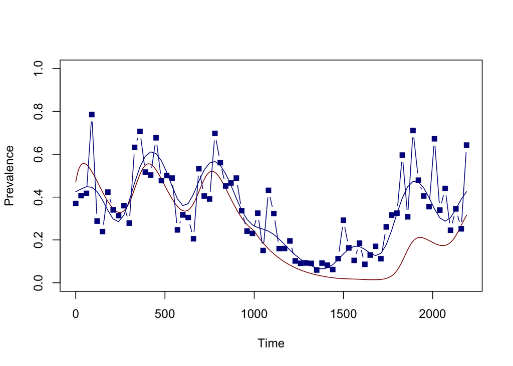

```r
mod_est <- xds_solve(mod_est, 2190, 10)
xds_plot_PR(mod_est, clrs= "darkred")
#xds_plot_PR(mod, clrs = "darkred", add=TRUE)
xds_plot_PR(mod1, clrs="darkblue", add=TRUE)
lines(tt, obs_pr, col = "darkblue", type = "b", pch=15)
```